# Data Visualization & Data Summary R Skills Review

January 19, 2021

## Data

Data were collected on 344 penguins living on three islands (Torgersen, Biscoe, and Dream) in the Palmer Archipelago, Antarctica. In addition to which island each penguin lives on, the data contains information on the species of the penguin (Adelie, Chinstrap, or Gentoo), its bill length, bill depth, and flipper length (measured in millimeters), its body mass (measured in grams), and the sex of the penguin (female or male).

## Data Wrangling

- 6 Verbs of Data Wrangling
  - `filter()` – filter out/in observations/rows
  - `select()` – select variables/columns
  - `mutate()` – modifies a dataset
  - `group_by()` – group data by a categorical variable
  - `summarize()` – create data summaries of variables
  - `arrange()` – arrange data in descending/ascending order

## `filter()`

Removes observations / rows from the dataset that **do not** satify the criteria

```r
penguins %>%
  filter(species == "Adelie")
```

## `select()`

Selects variables / columns from the dataset

```r
penguins %>%
  select(species, island, sex, year)
```

## `mutate()`

Modifies the dataset in two ways:

1. Adds new columns
2. Changes existing columns

```r
penguins %>%
  mutate(body_mass_kg = body_mass_g / 1000,
         sex = if_else(is.na(sex) == TRUE, "unsexed", sex)
         )
```

## `group_by()` & `summarize()`

Creates groups from a categorical variable, then summarizes each group

```r
penguins %>%
  group_by(sex) %>%
  summarize(mean_mass = mean(body_mass_g),
            mean_flipper = mean(flipper_length_mm)
            )
```

## `arrange()`

Arranges a dataset in ascending or descending order based variable(s) input

```r
penguins %>%
  filter(sex == "male", year == 2007) %>%
  group_by(species) %>%
  summarize(mean_bill_length = mean(bill_length_mm),
            sd_bill_length = sd(bill_length_mm),
            obs = n()) %>%
  arrange(desc(obs))
```

## Histogram

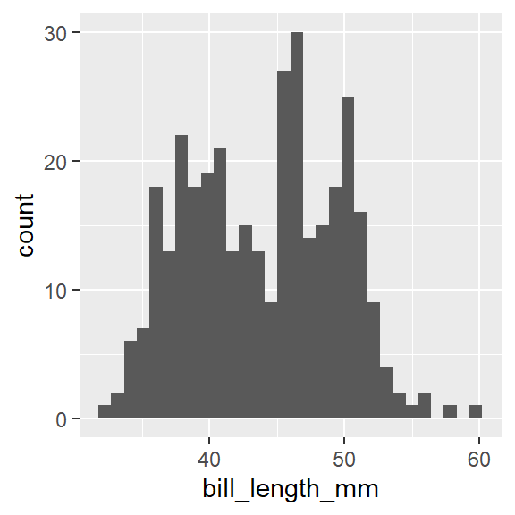

```r
penguins %>%
  ggplot(aes(x = bill_length_mm)) +
  geom_histogram()
```

## Dotplot

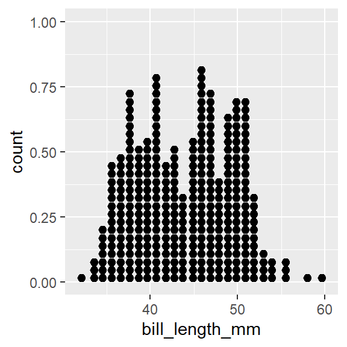

```r
penguins %>%
  ggplot(aes(x = bill_length_mm)) +
  geom_dotplot()
```

## Boxplot

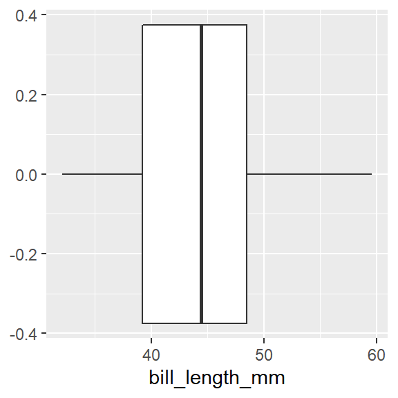

```r
penguins %>%
  ggplot(aes(x = bill_length_mm)) +
  geom_boxplot()
```

## Density Plot

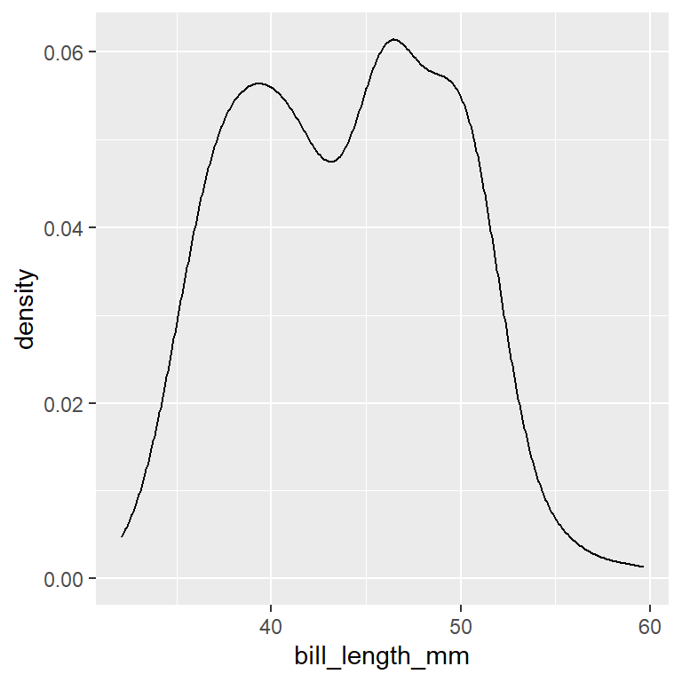

```r
penguins %>%
  ggplot(aes(x = bill_length_mm)) +
  geom_density()
```

## Side-by-Side Boxplots

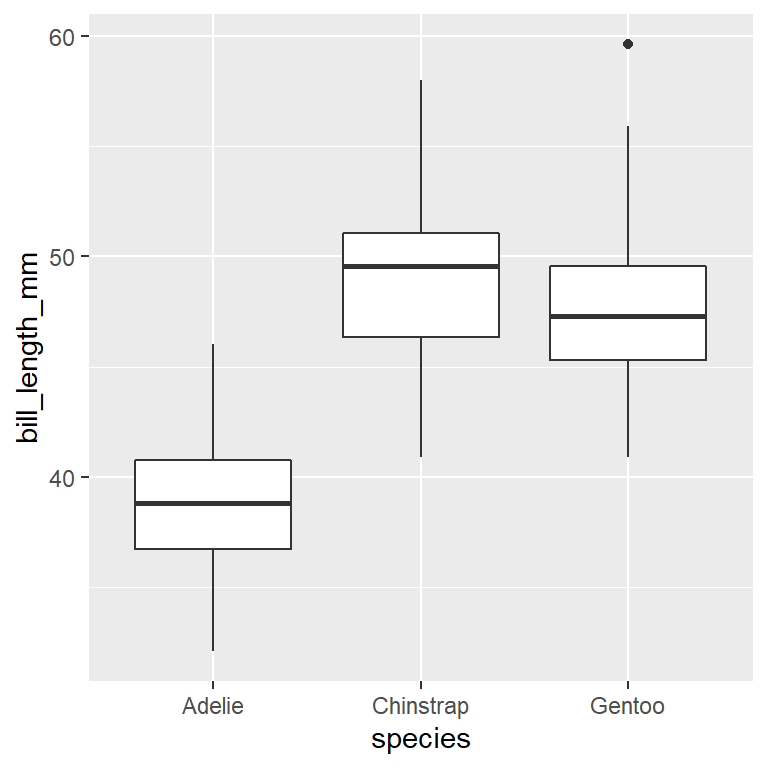

```r
penguins %>%
  ggplot(aes(y = bill_length_mm, x = species)) +
  geom_boxplot()
```

## Side-by-Side Density Plots – Ridge Plots

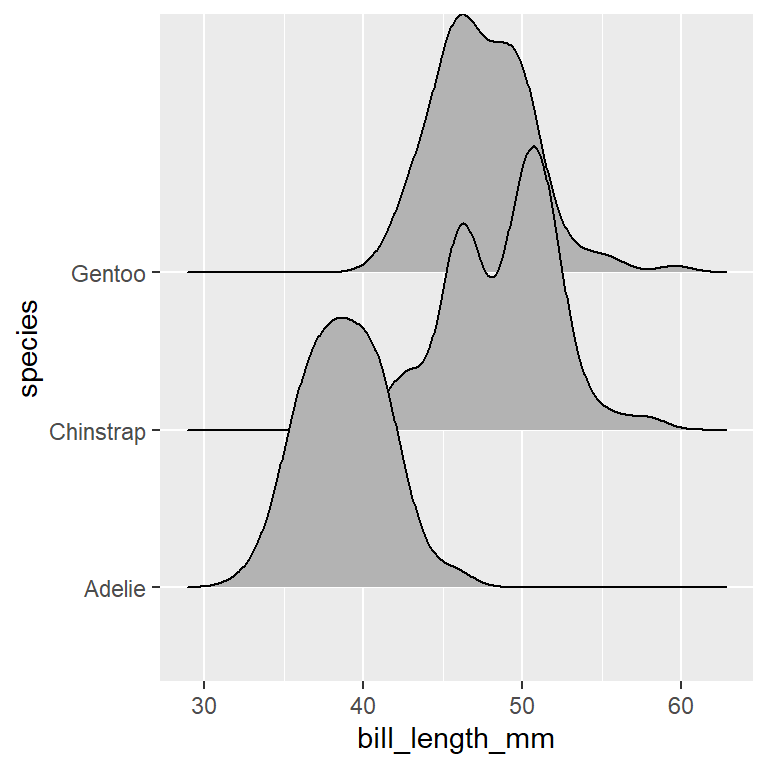

```r
penguins %>%
  ggplot(aes(x = bill_length_mm, y = species)) +
  geom_density_ridges()
```

## Scatterplots

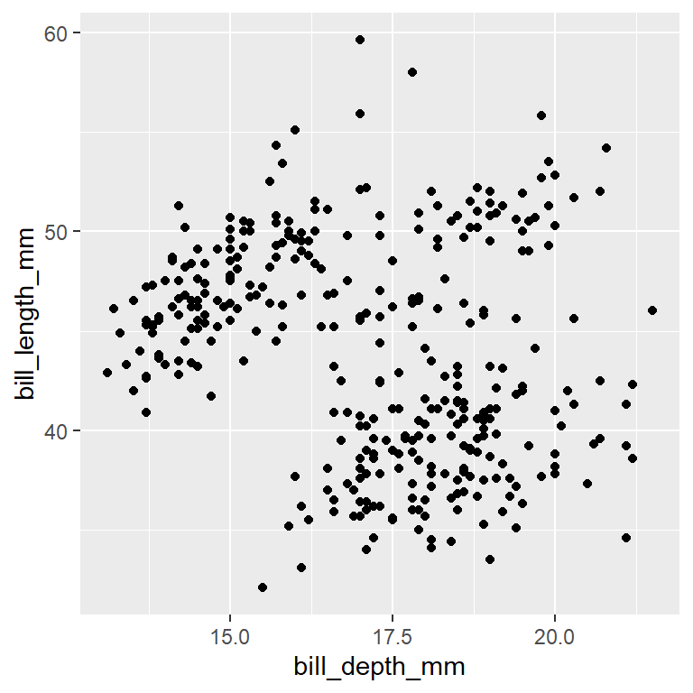

```r
penguins %>%
  ggplot(aes(y = bill_length_mm, x = bill_depth_mm)) +
  geom_point()
```

## Colors in Scatterplots

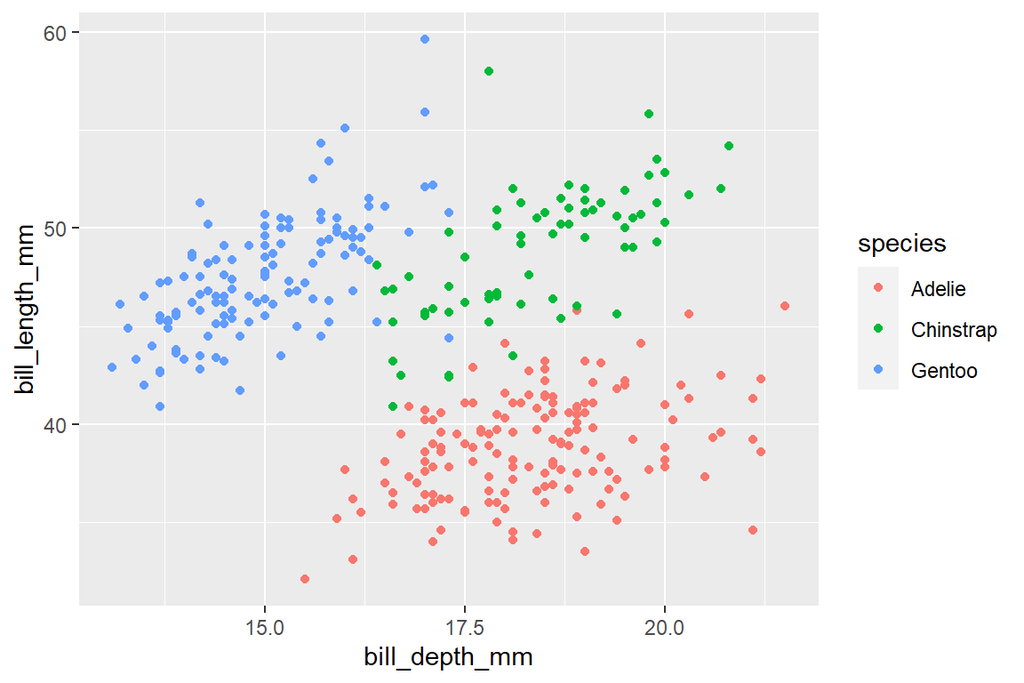

```r
penguins %>%
  ggplot(aes(y = bill_length_mm, x = bill_depth_mm, color = species)) +
  geom_point()
```

## Colors in Ridge Plots

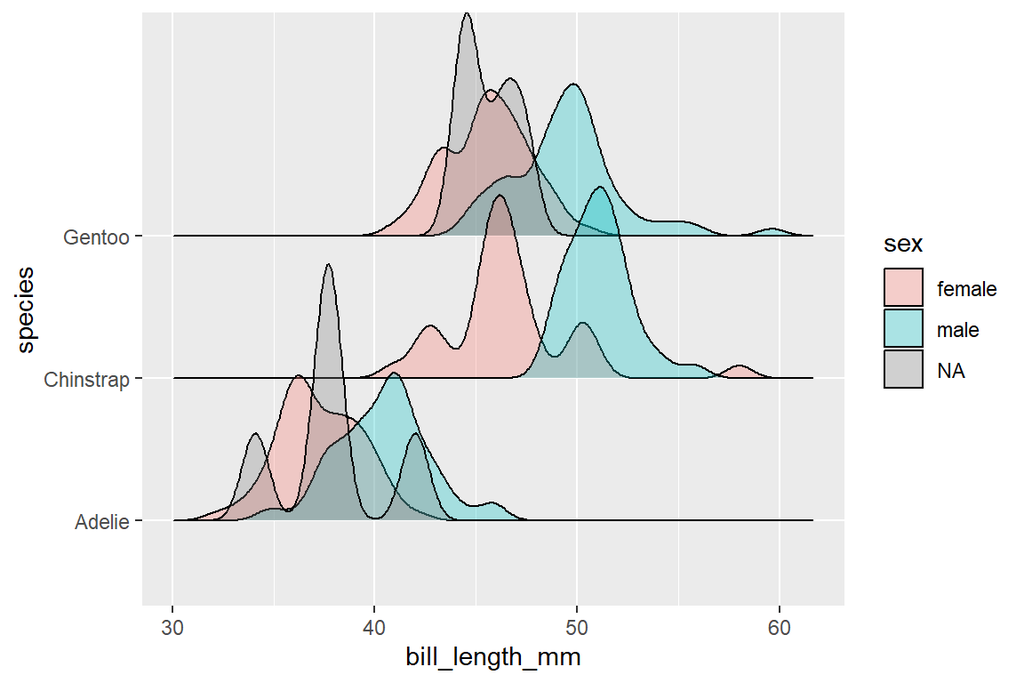

```r
penguins %>%
  ggplot(aes(x = bill_length_mm, y = species, fill = sex)) +
  geom_density_ridges(alpha = 0.3)
```

## Facets in Scatterplots

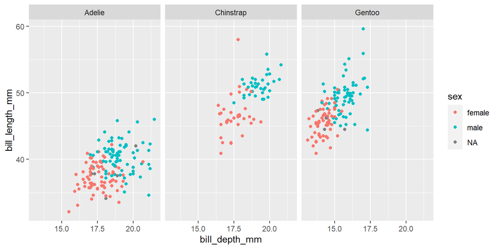

```r
penguins %>%
  ggplot(aes(y = bill_length_mm, x = bill_depth_mm, color = sex)) +
  geom_point() +
  facet_wrap(vars(species))
```

## Facets in Ridge Plots

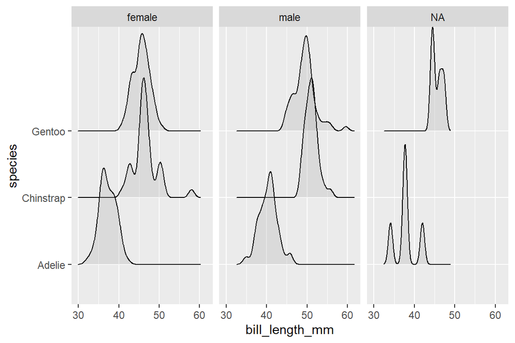

```r
penguins %>%
  ggplot(aes(x = bill_length_mm, y = species)) +
  geom_density_ridges(alpha = 0.3) +
  facet_wrap(vars(sex))
```